# P&S-2025: Lab assignment 2

Микита Ягода, Назар Михайлищук, Ірина Свириденко

## General comments and instructions

- Complete solution will give you **4 points** (working code with explanations + oral defense). Submission deadline **October 30, 2025, 23:59**
- The report must be prepared as an *R notebook*; you must submit to **lms** both the source *R notebook* **and** the generated html file
- At the beginning of the notebook, provide a work-breakdown structure estimating efforts of each team member
- For each task, include
  - problem formulation and discussion (what is a reasonable answer to discuss);
  - the corresponding $\mathbf{R}$ code with comments (usually it is just a couple of lines long);
  - the statistics obtained (like sample mean or anything else you use to complete the task) as well as histograms etc to illustrate your findings;
  - justification of your solution (e.g. refer to the corresponding theorems from probability theory);
  - conclusions (e.g. how reliable your answer is, does it agree with common sense expectations etc)
- The **team id number** referred to in tasks is the **two-digit** ordinal number of your team on the list. Include the line **set.seed(team id number)** at the beginning of your code to make your calculations reproducible. Also observe that the answers **do** depend on this number!
- Take into account that not complying with these instructions may result in point deduction regardless of whether or not your implementation is correct.

## Work breakdown

- Task 1
  - Микита Ягода(33 1/3%)
- Task 2 & 3
  - Ірина Свириденко(33 1/3%)
- Task 4
  - Назар Михайлищук(33 1/3%)

### Task 1

#### In this task, we discuss the $[7,4]$ Hamming code and investigate its reliability. That coding system can correct single errors in the transmission of $4$-bit messages and proceeds as follows:

- given a message $\mathbf{m} = (a_1 a_2 a_3 a_4)$, we first encode it to a $7$-bit *codeword* $\mathbf{c} = \mathbf{m}G = (x_1 x_2 x_3 x_4 x_5 x_6 x_7)$, where $G$ is a $4\times 7$ *generator* matrix
- the codeword $\mathbf{c}$ is transmitted, and $\mathbf{r}$ is the received message
- $\mathbf{r}$ is checked for errors by calculating the *syndrome vector* $\mathbf{z} := \mathbf{r} H$, for a $7 \times 3$ *parity-check* matrix $H$
- if a single error has occurred in $\mathbf{r}$, then the binary $\mathbf{z} = (z_1 z_2 z_3)$ identifies the wrong bit no. $z_1 + 2 z_2 + 4z_3$; thus $(0 0 0)$ shows there was no error (or more than one), while $(1 1 0 )$ means the third bit (or more than one) got corrupted
- if the error was identified, then we flip the corresponding bit in $\mathbf{r}$ to get the corrected $\mathbf{r}^* = (r_1 r_2 r_3 r_4 r_5 r_6 r_7)$;
- the decoded message is then $\mathbf{m}^*:= (r_3r_5r_6r_7)$.

#### The **generator** matrix $G$ and the **parity-check** matrix $H$ are given by

$$G :=
\begin{pmatrix}
1 & 1 & 1 & 0 & 0 & 0 & 0 \\
1 & 0 & 0 & 1 & 1 & 0 & 0 \\
0 & 1 & 0 & 1 & 0 & 1 & 0 \\
1 & 1 & 0 & 1 & 0 & 0 & 1 \\
\end{pmatrix},
\qquad
H^\top := \begin{pmatrix}
1 & 0 & 1 & 0 & 1 & 0 & 1 \\
0 & 1 & 1 & 0 & 0 & 1 & 1 \\
0 & 0 & 0 & 1 & 1 & 1 & 1
\end{pmatrix}$$

#### Assume that each bit in the transmission $\mathbf{c} \mapsto \mathbf{r}$ gets corrupted independently of the others with probability $p = \mathtt{id}/100$, where $\mathtt{id}$ is your team number. Your task is the following one.

1. Simulate the encoding-transmission-decoding process $N$ times and find the estimate $\hat p$ of the probability $p^*$ of correct transmission of a single message $\mathbf{m}$. Comment why, for large $N$, $\hat p$ is expected to be close to $p^*$.
2. By estimating the standard deviation of the corresponding indicator of success by the standard error of your sample and using the CLT, predict the interval $(p^*-\varepsilon, p^* + \varepsilon)$, in which the estimate $\hat p$ falls with probability at least $0.95$.
3. What choice of $N$ guarantees that $\varepsilon \le 0.03$?
4. Draw the histogram of the number $k = 0,1,2,3,4$ of errors while transmitting a $4$-digit binary message. Do you think it is one of the known distributions?

#### You can (but do not have to) use the chunks we prepared for you

#### First, we set the **id** of the team and define the probability $p$ and the generator and parity-check matrices $G$ and $H$

```r
id <- 32

set.seed(id)
p <- id/100
# matrices G and H
G <- matrix(c(1, 1, 1, 0, 0, 0, 0,
              1, 0, 0, 1, 1, 0, 0,
              0, 1, 0, 1, 0, 1, 0,
              1, 1, 0, 1, 0, 0, 1),
            nrow = 4, byrow = TRUE)
H <- t(matrix(c(1, 0, 1, 0, 1, 0, 1,
                0, 1, 1, 0, 0, 1, 1,
                0, 0, 0, 1, 1, 1, 1),
            nrow = 3, byrow = TRUE))
# cat("The matrix G is: \n")
#G
#cat("The matrix H is: \n")
#H
#cat("The product GH must be zero: \n")
#(G%*%H) %%2
```

#### Next, generate the messages

```r
# generate N messages
n <- 100
message_generator <- function(N) {
  matrix(sample(c(0,1), 4*N, replace = TRUE), nrow = N)
}
messages <- message_generator(n)
codewords <- (messages %*% G) %% 2
```

#### Generate random errors; do not forget that they occur with probability $p$! Next, generate the received messages

##### 1

```r
#  errors <- ...
# errors <- t(replicate(n, sample(c(0,1), prob = c(1-p,p), size = 7, replace = T)));
# errors <- matrix(sample(c(0,1), prob = c(1-p,p), size = 7*n, replace = T), nrow = n)
# errors

# errors_count <- rpois(7, p)  # number of corruptions per bit
# errors <- errors_count %% 2        # 1 if odd (flipped), 0 if even
# data.frame(errors_count, errors)

# errors <- t(replicate(n, rpois(7, p) %% 2))
errors <- t(replicate(n, rbinom(7, 1, p)))

#  received <-
received <- xor(codewords, errors) * 1 # * 1 -- to convert TRUE and FALSE to 1 and 0
```

The next steps include detecting the errors in the received messages, correcting them, and then decoding the obtained messages. After this, you can continue with calculating all the quantities of interest

```r
z <- received %*% H %% 2

# function to map syndrome (z1,z2,z3) to position 0..7
syndrome_to_pos <- function(zvec) {
  # zvec is length-3 vector (z1,z2,z3), bit order matches definition:
  # position = z1 + 2*z2 + 4*z3
  pos <- zvec[1] + 2*zvec[2] + 4*zvec[3]
  return(pos)   # 0 means "no single-bit error detected"
}
corrected <- received  # start with received, then flip where needed
for(i in 1:n) {
  pos <- syndrome_to_pos(as.integer(z[i, ]))
  if(pos >= 1 && pos <= 7) {
    corrected[i, pos] <- (corrected[i, pos] + 1) %% 2
  }
}

# now decode: m* = (r3 r5 r6 r7) as given
decoded <- cbind(corrected[,3], corrected[,5], corrected[,6], corrected[,7])

# success indicator: compare decoded message to original messages
success <- apply(decoded == messages, 1, all)   # TRUE if all 4 bits recovered
success_num <- as.integer(success)

# estimate p* and standard error & 95% CI using CLT
p_hat <- mean(success_num)

p_hat
```

```
## [1] 0.28
```

$\hat p$ approaches $p*$ because our distribution $X$ consists of samples $X_i$ which are i.i.d. r.v. with Bernouli distribution. Therefore due to the Strong law of large numbers our ecdf converges almost everywhere to the mean of $X_i \sim \mathscr{B}(1, p^*)$. $\hat p = \hat F_{n} \xrightarrow{} E(X_1) = p^*$

##### 2

$Var(\Theta) = \frac{\sum_{i=1}^N Var(X_i)}{N^2} = \frac{p^*(1-p^*)}{N}$

$MSE(\hat{p}) = BIAS(\hat{p})^2 + Var(\hat{p}) \xrightarrow{\hat{p}\ is\ unbiased} MSE(\hat{p}) = Var(\hat{p})$

Due to CLT we can use k-sigma rule to predict the interval $(p^* - 2*sd, p^* + 2*sd)$ in which $\hat{p}$ falls with probability 0.95

```r
sd <- sqrt(p_hat*(1 - p_hat) / n)
sd
```

```
## [1] 0.04489989
```

```r
mse <- sd^2

c(p_hat - 2*sd, p_hat + 2*sd)
```

```
## [1] 0.1902002 0.3697998
```

##### 3

$\varepsilon = z_{0.975} * \hat{\sigma} = z_{0.975} * \sqrt{\frac{\hat{p}(1-\hat{p})}{N}}$

$N = \frac{\hat{p}(1-\hat{p}) z_{0.975}^2}{\varepsilon^2}$

```r
epsilon <- 0.03
N_approx <- p_hat * (1-p_hat) * 1.96^2 / epsilon^2
N_approx
```

```
## [1] 860.5184
```

##### 4

```r
# simulate n independent 4-bit messages and count errors per message
errors_per_msg <- replicate(n, sum(rbinom(4, size = 1, prob = p)))
# frequency table for k=0..4
tab <- table(factor(errors_per_msg, levels = 0:4))
tab
```

```
##
##  0  1  2  3  4
## 19 47 25  8  1
```

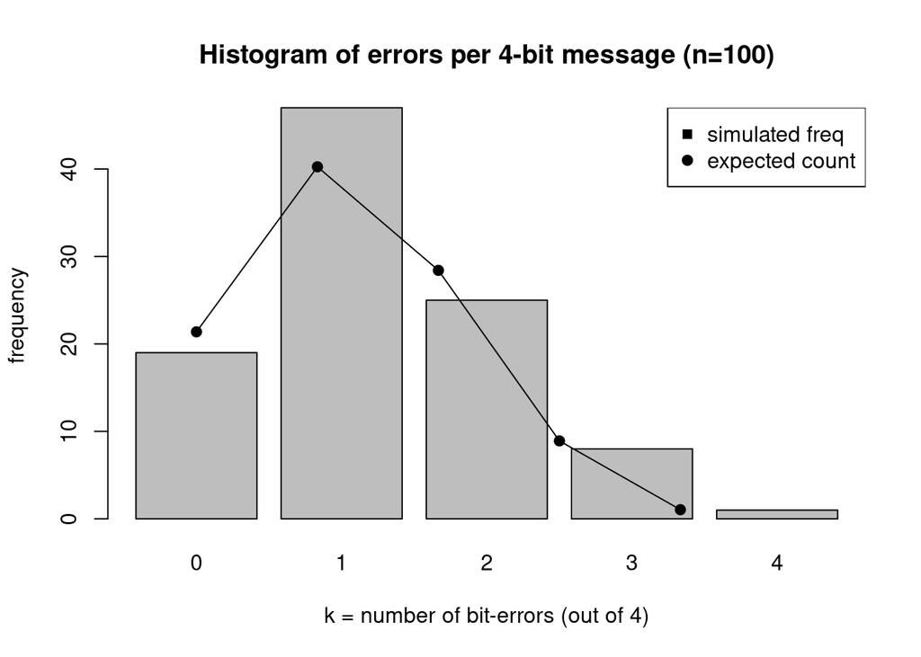

```r
# plot histogram (barplot of frequencies) and overlay expected probabilities scaled by n
barplot(tab, names.arg = 0:4, xlab = "k = number of bit-errors (out of 4)",
        ylab = "frequency", main = paste("Histogram of errors per 4-bit message (n=", n, ")", sep=""))
expected_probs <- dbinom(0:4, size = 4, prob = p)
expected_counts <- expected_probs * n
points(0:4 + 0.7, expected_counts, pch = 19)   # plot expected counts as points
lines(x = 0:4 + 0.7, y = expected_counts)       # connect them
legend("topright", legend = c("simulated freq", "expected count"),
       pch = c(15,19), col = c("black","black"))
```

**Do not forget to include several sentences summarizing your work and the conclusions you have made!**

### Task 2.

In this task, we discuss a real-life process that is well modelled by a Poisson distribution. As you remember, a Poisson random variable describes occurrences of rare events, i.e., counts the number of successes in a large number of independent random experiments. One of the typical examples is the **radioactive decay** process.

Consider a sample of radioactive element of mass $m$, which has a big *half-life period* $T$; it is vitally important to know the probability that during a one second period, the number of nuclei decays will not exceed some critical level $k$. This probability can easily be estimated using the fact that, given the *activity* ${\lambda}$ of the element (i.e., the probability that exactly one nucleus decays in one second) and the number $N$ of atoms in the sample, the random number of decays within a second is well modelled by Poisson distribution with parameter $\mu:=N\lambda$. Next, for the sample of mass $m$, the number of atoms is $N = \frac{m}{M} N_A$, where $N_A = 6 \times 10^{23}$ is the Avogadro constant, and $M$ is the molar (atomic) mass of the element. The activity of the element, $\lambda$, is $\log(2)/T$, where $T$ is measured in seconds.

Assume that a medical laboratory receives $n$ samples of radioactive element ${{}^{137}}\mathtt{Cs}$ (used in radiotherapy) with half-life period $T = 30.1$ years and mass $m = \mathtt{team\, id \,number} \times 10^{-6}$ g each. Denote by $X_1,X_2,\dots,X_n$ the **i.i.d. r.v.**’s counting the number of decays in sample $i$ in one second.

1. Specify the parameter of the Poisson distribution of $X_i$ (you’ll need the atomic mass of *Cesium-137*)
2. Show that the distribution of the sample means of $X_1,\dots,X_n$ gets very close to a normal one as $n$ becomes large and identify that normal distribution. To this end,
   - simulate the realization $x_1,x_2,\dots,x_n$ of the $X_i$ and calculate the sample mean $s=\overline{\mathbf{x}}$;
   - repeat this $K$ times to get the sample $\mathbf{s}=(s_1,\dots,s_K)$ of means and form the empirical cumulative distribution function $\hat F_{\mathbf{s}}$ of $\mathbf{s}$;
   - identify $\mu$ and $\sigma^2$ such that the $F$ of $\mathscr{N}(\mu,\sigma^2)$ is close to the $\hat F_{\mathbf{s}}$ and plot both **c.d.f.**’s on one graph to visualize their proximity (use the proper scales!);
   - calculate the maximal difference between the two ’s;
   - consider cases $n = 5$, $n = 10$, $n=50$ and comment on the results.
3. Calculate the largest possible value of $n$, for which the total number of decays in one second is less than $8 \times 10^8$ with probability at least $0.95$. To this end,
   - obtain the theoretical bound on $n$ using Markov inequality, Chernoff bound and Central Limit Theorem, and compare the results;
   - simulate the realization $x_1,x_2,\dots,x_n$ of the $X_i$ and calculate the sum $s=x_1 + \cdots +x_n$;
   - repeat this $K$ times to get the sample $\mathbf{s}=(s_1,\dots,s_K)$ of sums;
   - calculate the number of elements of the sample which are less than critical value ($8 \times 10^8$) and calculate the empirical probability; comment whether it is close to the desired level $0.95$

#### Part 1

```r
lambda <- log(2)/(30.1*365*24*3600)
lambda
```

```
## [1] 7.302177e-10
```

#### Part 2

```r
m <- id * 1e-6
M <- 136.9
Na <- 6e23
N <- m*Na/M
mu <- N * lambda
K <- 20e3
n <- 5
n_cases <- c(5, 10, 50)
sim_sample_mean <- function(n, mu) {
  x <- rpois(n, lambda = mu)
  mean(x)
}
for (n in n_cases) {
  xvec <- rpois(n, lambda = mu)
  s_mean <- mean(xvec)
  cat("n =", n, ": sample x =", paste(round(xvec, 0), collapse = ", "), "; sample mean =", round(s_mean, 6), "\n")
}
```

```
## n = 5 : sample x = 102432739, 102420622, 102404771, 102394638, 102423803 ; sample mean = 102415315
## n = 10 : sample x = 102428727, 102410491, 102409524, 102412315, 102417105, 102390488, 102408417, 102428266, 102417062, 102408291 ; sample mean = 102413069
## n = 50 : sample x = 102431298, 102420960, 102409594, 102418828, 102400211, 102425807, 102402465, 102420941, 102423911, 102407100, 102413811, 102406000, 102412632, 102414188, 102420038, 102406609, 102403670, 102402126, 102421225, 102409635, 102412784, 102400997, 102415871, 102415486, 102411300, 10…
```

- repeat this $K$ times to get the sample $\mathbf{s}=(s_1,\dots,s_K)$ of means and form the empirical cumulative distribution function $\hat F_{\mathbf{s}}$ of $\mathbf{s}$;

```r
results <- list()
summary_table <- data.frame(
  n = numeric(),
  mean_of_means = numeric(),
  var_of_means = numeric(),
  stringsAsFactors = FALSE
)

for (n in n_cases) {
  s <- numeric(K)
  for (i in seq_len(K)) s[i] <- sim_sample_mean(n, mu)

  results[[as.character(n)]] <- list(
    n = n,
    s = s,
    ecdf_fun = ecdf(s)
  )

  summary_table <- rbind(
    summary_table,
    data.frame(
      n = n,
      mean_of_means = mean(s),
      var_of_means = var(s)
    )
  )
}

print(summary_table, row.names = FALSE)
```

```
##   n mean_of_means var_of_means
##   5     102411864     20480683
##  10     102411785     10301324
##  50     102411831      2050449
```

##### We can now plot ecdf and cdf

- identify $\mu$ and $\sigma^2$ such that the $F$ of $\mathscr{N}(\mu,\sigma^2)$ is close to the $\hat F_{\mathbf{s}}$ and plot both **c.d.f.**’s on one graph to visualize their proximity (use the proper scales!);

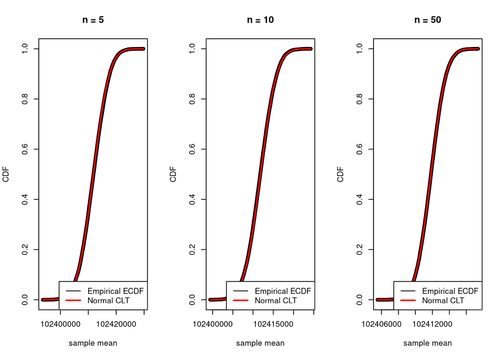

```r
par(mfrow = c(1,3))
for (n in n_cases) {
  s <- results[[as.character(n)]]$s
  s_sorted <- sort(s)
  ecdf_vals <- results[[as.character(n)]]$ecdf_fun(s_sorted)
  mu_clt <- mu
  sd_clt <- sqrt(mu / n)
  normal_cdf_vals <- pnorm(s_sorted, mean = mu_clt, sd = sd_clt)
  # plot ECDF (step) and theoretical normal CDF (red)
  plot(s_sorted, ecdf_vals, type = "s", ylim = c(0,1),
       main = paste("n =", n), xlab = "sample mean", ylab = "CDF",
       lwd=5)
  lines(s_sorted, normal_cdf_vals, col = "red", lwd = 2)
  legend("bottomright", legend = c("Empirical ECDF", "Normal CLT"), col = c("black","red"), lwd = c(1,2))
}
```

```r
par(mfrow = c(1,1))
```

- calculate the maximal difference between the two ’s;

```r
max_distance <- data.frame(n = integer(), D = numeric(), stringsAsFactors = FALSE)
for (n in n_cases) {
  s <- results[[as.character(n)]]$s
  s_sorted <- sort(s)
  ecdf_vals <- results[[as.character(n)]]$ecdf_fun(s_sorted)
  normal_cdf_vals <- pnorm(s_sorted, mean = mu, sd = sqrt(mu / n))
  D <- max(abs(ecdf_vals - normal_cdf_vals))
  max_distance <- rbind(max_distance, data.frame(n = n, D = D))
  cat("n =", n, ": max D =", round(D, 6), "\n")
}
```

```
## n = 5 : max D = 0.009378
## n = 10 : max D = 0.009304
## n = 50 : max D = 0.00313
```

#### Part 3

- Markov inequality

  ```r
  p_target <- 0.95
  critical_value <- 8e8
  n_markov <- (1-p_target) * critical_value / mu
  ```

- Chernoff inequality

  ```r
  f_chernoff_log <- function(n, mu_param, k_param, log_p) {
    lambda_n <- n * mu_param
    log_lhs <- (k_param - lambda_n) + k_param * (log(lambda_n) - log(k_param))
    return(log_lhs - log_p)
  }

  max_n_domain <- critical_value / mu
  upper_bound <- max_n_domain - 1e-6
  solution <- uniroot(
    f_chernoff_log,
    interval = c(1, upper_bound),
    mu_param = mu,
    k_param = critical_value,
    log_p = log(1 - p_target)
  )
  n_chernoff <- solution$root
  ```

- CLT approx

  ```r
  f_clt <- function(n) {
    pnorm((critical_value - n * mu) / sqrt(n * mu)) - p_target
  }
  n_clt <- uniroot(f_clt, c(1, 1000))$root
  ```

```r
n_cases <- c(n_markov, n_chernoff, n_clt, 8)
results <- data.frame(
  Method = c("Markov", "Chernoff", "CLT", "8"),
  n_theoretical = n_cases,
  empirical_p = NA
)

for (i in seq_along(n_cases)) {
  n <- n_cases[i]
  s <- replicate(K, sum(rpois(n, lambda = mu)))
  p_emp <- mean(s < critical_value)
  results$empirical_p[i] <- p_emp
}

# === Part 4: Output ===

print(results, row.names = FALSE)
```

```
##    Method n_theoretical empirical_p
##    Markov     0.3905799           1
##  Chernoff     7.8109249           1
##       CLT     7.8111576           1
##         8     8.0000000           0
```

```r
s_vec <- numeric(K)

for (i in seq_len(K)) {
  x <- rpois(n, lambda = mu)
  s_vec[i] <- sum(x)
}

p_empirical <- mean(s_vec < critical_value)

cat("Empirical probability P(S < 8e8) =", round(p_empirical, 4), "\n")
```

```
## Empirical probability P(S < 8e8) = 0
```

**Do not forget to include several sentences summarizing your work and the conclusions you have made!**

### Task 3.

#### In this task, we use the Central Limit Theorem approximation for continuous random variables.

#### One of the devices to measure radioactivity level at a given location is the Geiger counter. When the radioactive level is almost constant, the time between two consecutive clicks of the Geiger counter is an exponentially distributed random variable with parameter $\nu_1 = \mathtt{team\,id\,number} + 10$. Denote by $X_k$ the random time between the $(k-1)^{\mathrm{st}}$ and $k^{\mathrm{th}}$ click of the counter.

1. Show that the distribution of the sample means of $X_1, X_2,\dots,X_n$ gets very close to a normal one (which one?) as $n$ becomes large. To this end,
   - simulate the realizations $x_1,x_2,\dots,x_n$ of the $X_i$ and calculate the sample mean $s=\overline{\mathbf{x}}$;
   - repeat this $K$ times to get the sample $\mathbf{s}=(s_1,\dots,s_K)$ of means and then the function $F_{\mathbf{s}}$ of $\mathbf{s}$;
   - identify $\mu$ and $\sigma^2$ such that the of $\mathscr{N}(\mu,\sigma^2)$ is close to the $F_{\mathbf{s}}$ of and plot both ’s on one graph to visualize their proximity;
   - calculate the maximal difference between the two ’s;
   - consider cases $n = 5$, $n = 10$, $n=50$ and comment on the results.
2. The place can be considered safe when the number of clicks in one minute does not exceed $100$. It is known that the parameter $\nu$ of the resulting exponential distribution is proportional to the number $N$ of the radioactive samples, i.e., $\nu = \nu_1*N$, where $\nu_1$ is the parameter for one sample. Determine the maximal number of radioactive samples that can be stored in that place so that, with probability $0.95$, the place is identified as safe. To do this,
   - express the event of interest in terms of the $S:= X_1 + \cdots + X_{100}$;
   - obtain the theoretical bounds on $N$ using the Markov inequality, Chernoff bound and Central Limit Theorem and compare the results;
   - with the predicted $N$ and thus $\nu$, simulate the realization $x_1,x_2,\dots,x_{100}$ of the $X_i$ and of the sum $S = X_1 + \cdots + X_{100}$;
   - repeat this $K$ times to get the sample $\mathbf{s}=(s_1,\dots,s_K)$ of total times until the $100^{\mathrm{th}}$ click;
   - estimate the probability that the location is identified as safe and compare to the desired level $0.95$

#### First, generate samples an sample means:

```r
nu1 <- id + 10

K <- 5000
true_mean <- 1 / nu1
true_var  <- 1 / (nu1^2)

simulate_clt <- function(n, K = 5000, dist = rexp, dist_params = list(rate = nu1)) {
  s <- numeric(K)
  for (i in seq_len(K)) {
    x <- do.call(dist, c(list(n = n), dist_params))
    s[i] <- mean(x)
  }
  list(n = n, s = s)
}
results_n5  <- simulate_clt(5,  K = K)
results_n10 <- simulate_clt(10, K = K)
results_n50 <- simulate_clt(50, K = K)
```

#### Next, calculate the parameters of the standard normal approximation

```r
calculate_clt_params <- function(res, true_mean, true_var) {
  xs <- sort(res$s)
  ecdf_s <- ecdf(res$s)
  mu_clt <- true_mean
  sigma_clt <- sqrt(true_var / res$n)

  normal_cdf_vals <- pnorm(xs, mean = mu_clt, sd = sigma_clt)
  ecdf_vals <- ecdf_s(xs)
  D <- max(abs(ecdf_vals - normal_cdf_vals))

  c(res, list(xs = xs, ecdf_vals = ecdf_vals,
              normal_cdf_vals = normal_cdf_vals, D = D,
              mu_clt = mu_clt, sigma_clt = sigma_clt))
}

results_n5  <- calculate_clt_params(results_n5,  true_mean, true_var)
results_n10 <- calculate_clt_params(results_n10, true_mean, true_var)
results_n50 <- calculate_clt_params(results_n50, true_mean, true_var)

cat("n=5:  D =", round(results_n5$D, 4), "\n")
```

```
## n=5:  D = 0.0636
```

```r
cat("n=10: D =", round(results_n10$D, 4), "\n")
```

```
## n=10: D = 0.0405
```

```r
cat("n=50: D =", round(results_n50$D, 4), "\n\n")
```

```
## n=50: D = 0.0213
```

#### We can now plot ecdf and cdf

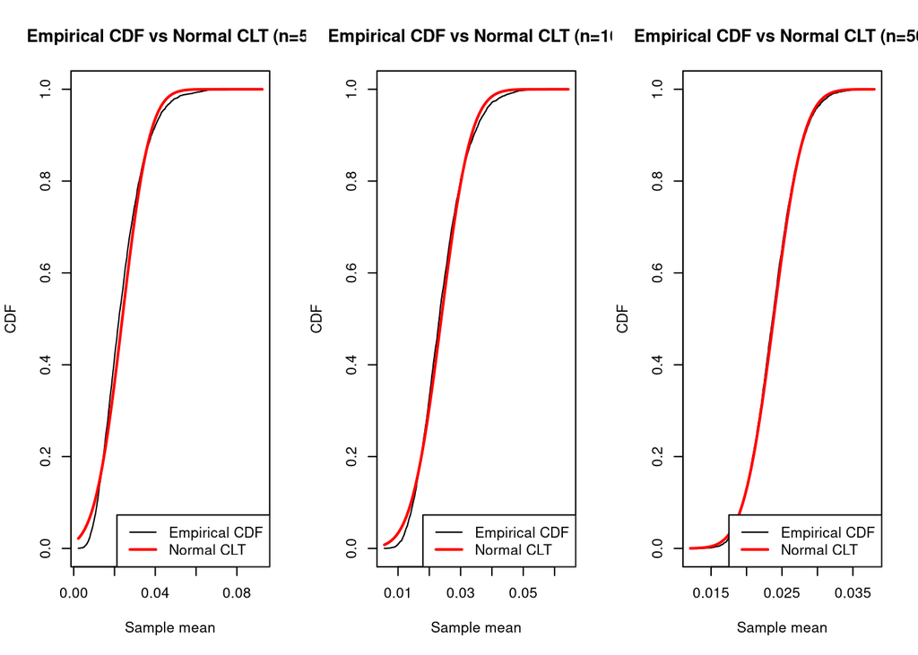

```r
plot_ecdf_vs_normal <- function(res) {
  plot(res$xs, res$ecdf_vals, type = "s", ylim = c(0,1),
       xlab = "Sample mean", ylab = "CDF",
       main = paste("Empirical CDF vs Normal CLT (n=", res$n, ")", sep=""))
  lines(res$xs, res$normal_cdf_vals, col = "red", lwd = 2)
  legend("bottomright", legend = c("Empirical CDF", "Normal CLT"),
         col = c("black", "red"), lwd = c(1,2))
}

hist_with_normal <- function(res) {
  h <- hist(res$s, breaks = 30, plot = FALSE)
  plot(h, freq = FALSE, main = paste("Histogram sample means (n=", res$n, ")", sep=""), xlab = "sample mean")
  curve(dnorm(x, mean = res$mu_clt, sd = res$sigma_clt), add = TRUE, lwd = 2, col = "red")
}

par(mfrow = c(1,3))
plot_ecdf_vs_normal(results_n5)
plot_ecdf_vs_normal(results_n10)
plot_ecdf_vs_normal(results_n50)
```

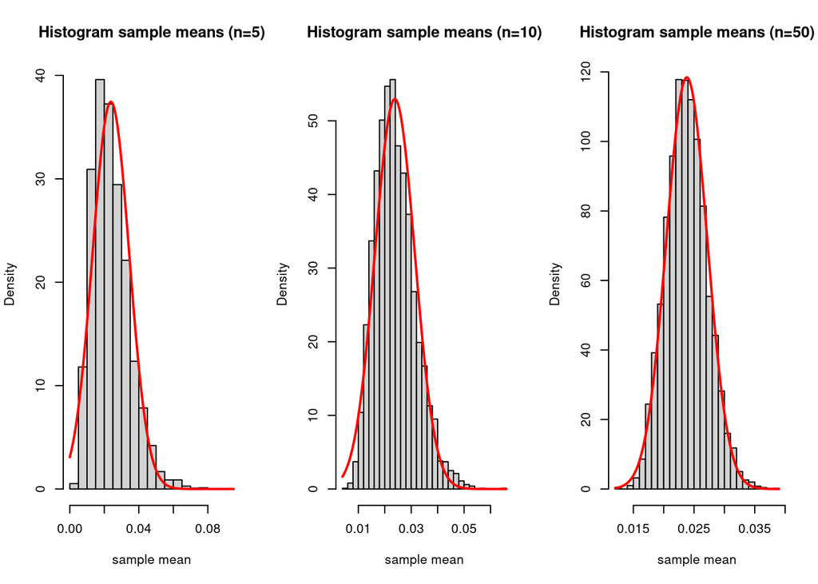

```r
par(mfrow = c(1,1))

par(mfrow = c(1,3))
hist_with_normal(results_n5)
hist_with_normal(results_n10)
hist_with_normal(results_n50)
```

```r
par(mfrow = c(1,1))
```

As n increases the distance D decreases -> empirical CDF gets closer to normal CDF

#### Solution of the second part

- Markov inequality

  ```r
  N_markov <- 100/(0.95*nu1)
  cat("Markov bound => max N (integer) =", N_markov, " (using nu1 =", nu1, ")\n")
  ```

  ```
  ## Markov bound => max N (integer) = 2.506266  (using nu1 = 42 )
  ```

- Chernoff inequality

  ```r
  f <- function(N) {
    nu <- 42 * N
    log_lhs <- 100 * (log(nu) - log(100)) + 100 - nu
    return(exp(log_lhs) - 0.05)
  }
  solution <- uniroot(f, interval = c(1, 2))
  N_chernoff <- solution$root
  ```

- CLT approx

  ```r
  p_threshold <- 0.05
  z_score <- qnorm(p_threshold)
  nu_max <- 100 + sqrt(100) * z_score
  N_max_continuous <- nu_max / nu1
  N_clt <- N_max_continuous
  ```

```r
cat("Lambda (mean counts in 60s) thresholds:\n",
    "Markov:", N_markov, "\n",
    "Chernoff:", N_chernoff, "\n",
    "CLT:", N_clt, "\n\n")
```

```
## Lambda (mean counts in 60s) thresholds:
##  Markov: 2.506266
##  Chernoff: 1.844713
##  CLT: 1.989321
```

**Simulation of X and S**

```r
simulate_probability_safe <- function(N, trials = 20000) {
  nu <- N * nu1
  S_values <- rgamma(trials, shape = 100, rate = nu)
  safe_events <- (S_values >= 1)
  mean(safe_events)
}

candidates <- unique(c(floor(N_markov), floor(N_chernoff),
                       N_markov + 1, N_chernoff + 1, N_clt + 1, 2))
candidates <- candidates[candidates >= 0]


sim_results <- sapply(candidates, function(N) simulate_probability_safe(N, trials = 20000))
results_table <- data.frame(
  Candidate_N = candidates,
  Probability = round(sim_results, 4),
  row.names = NULL)
print(results_table)
```

```
##   Candidate_N Probability
## 1    2.000000      0.9525
## 2    1.000000      1.0000
## 3    3.506266      0.0000
## 4    2.844713      0.0306
## 5    2.989321      0.0088
```

```r
simulate_S_times <- function(N, trials = 10000) {
  nu <- nu1 * N
  svals <- rgamma(trials, shape = 100, rate = nu)
  mean(svals > 1)
}

N_test <- 2
prob_safe_S <- simulate_S_times(N_test, trials = 20000)
cat("Probability (S >= 1) for N =", 2, "estimated =", round(prob_safe_S,4),
    " -> this is the prob that 100 clicks take longer than 60s (so <=99 clicks in 60s).\n")
```

```
## Probability (S >= 1) for N = 2 estimated = 0.9516  -> this is the prob that 100 clicks take longer than 60s (so <=99 clicks in 60s).
```

- Markov bound isn’t rigorous
- Chernoff and CLT approxes are much tighter than Markov

  From the table we see, that the maximum N for which P(S>=1) >= 0.95 is 2. According to Chernoff and CLT approximations max(N) = 1, but it’s only approximation, so it’s normal that in practice max(N) = 2.

**Getting the sample s of total times until the 100th click**

```r
N_predicted <- 2
nu_predicted <- N_predicted * nu1

s <- rgamma(K, shape = 100, rate = nu_predicted)

print(head(s))
```

```
## [1] 1.004061 1.229427 1.276183 1.470390 1.184372 1.368813
```

**Probability estimation**

```r
safe_events <- (s >= 1)

estimated_prob <- mean(safe_events)

desired_level <- 0.95

cat(sprintf("Estimated probability P(S >= 1): %.4f\n", estimated_prob))
```

```
## Estimated probability P(S >= 1): 0.9524
```

```r
cat(sprintf("Desired probablity level: %.4f\n", desired_level))
```

```
## Desired probablity level: 0.9500
```

**Next, proceed with all the remaining steps**

**Do not forget to include several sentences summarizing your work and the conclusions you have made!**

### Task 4.

**This task consists of two parts:**

1. **In this part, we discuss independence of random variables and its moments: expectation and variance.**
   1. Suppose we have a random variable $X$. Explain why $\mathbb{E}(\frac{1}{X}) \neq \frac{1}{\mathbb{E(X)}}$;
   2. Let $X \sim \mathscr{N}(\mu,\sigma^2)$ with $\mu = teamidnumber$ and $\sigma^{2} = 2\times teamidnumber+7$. Simulate realizations $x_1,x_2,\dots,x_{100}$ of $X$ and $y_1,y_2,\dots,y_{100}$ of $Y := \frac{1}{X}$ to calculate the values of $\frac{1}{\overline{\textbf{X}}}$ and $\overline{\textbf{Y}}$. Comment on the received results;

      ```r
      mu <- id
      sigma <- 2*id + 7
      N <- 100

      x <- rnorm(N, mean = mu, sd = sqrt(sigma))
      y <- 1/x

      x_bar <- mean(x)
      y_bar <- mean(y)

      x_bar
      ```

      ```
      ## [1] 32.41176
      ```

      ```r
      y_bar
      ```

      ```
      ## [1] 0.03600639
      ```

   3. Let $X$ and $Y$ be exponentially distributed r.v.’s with parameter $\lambda = 2$. Set $Z := \log{X} + 5$. Plot the Quantile-Quantile plot and scatterplot of $X$ and $Y$. Plot the Quantile-Quantile plot and scatterplot of $X$ and $Z$. Explain the results. Comment on the difference of relations between the pairs of random variables. Which pair of r.v.’s is dependent and which one is similar?

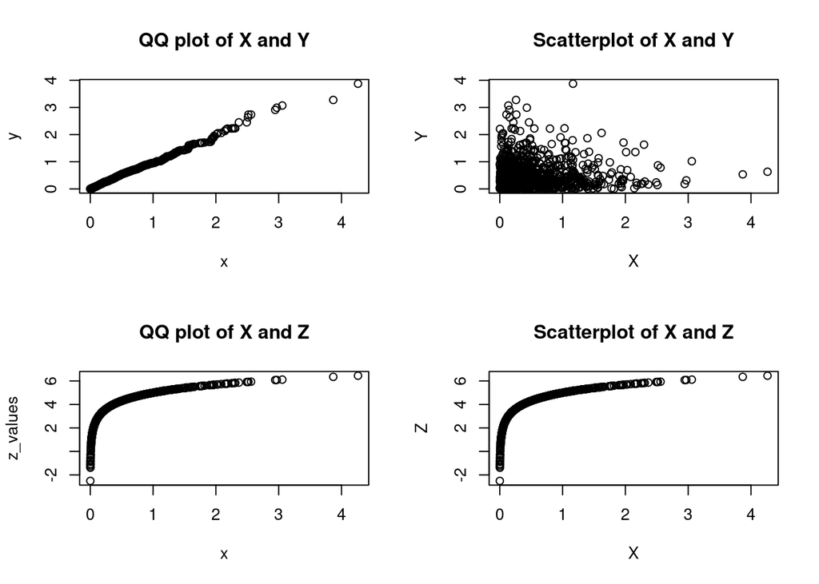

      ```r
      lambda <- 2
      z = function(x) { log(x) + 5 }
      N <- 1000
      x <- rexp(N, rate = lambda)
      y <- rexp(N, rate = lambda)
      z_values <- z(x)
      par(mfrow=c(2,2))
      qqplot(x, y, main = "QQ plot of X and Y")
      plot(x, y, main = "Scatterplot of X and Y", xlab =
              "X", ylab = "Y")
      qqplot(x, z_values, main = "QQ plot of X and Z")
      plot(x, z_values, main = "Scatterplot of X and Z", xlab
              = "X", ylab = "Z")
      ```

2. You toss a fair coin three times and a random variable $X$ records how many times the coin shows Heads. You convince your friend that they should play a game with the following payoff: every round (equivalent to three coin tosses) will cost £$1$. They will receive £$0.5$ for every coin showing Heads. What is the expected value and the variance of the random variable $Y := 0.5X-1$?

   To answer this,
   1. Explain what type of random variable is X:
      - Normally distributed
      - Binomially distributed
      - Poisson distributed
      - Uniformly distributed
   2. What are the expected value and variance of X? Simulate realizations $x_1,x_2,\dots,x_{100}$ of $X$ to calculate the values of sample mean $\overline{\mathbf{X}}$ and sample variance $s^2 = \frac{\sum_{i=1}^{n}{(x_i - \overline{x})^{2}}}{n-1}$. Comment on the results;

      ```r
      n_sim <- 100 # Renamed from 'n' to avoid conflict with n=3 trials
      x_sim <- rbinom(n_sim, size = 3, prob = 0.5)
      x_bar <- mean(x_sim)
      s2 <- var(x_sim)

      cat("Theoretical E[X]:", 1.5, "\n")
      ```

      ```
      ## Theoretical E[X]: 1.5
      ```

      ```r
      cat("Simulation (x_bar):", x_bar, "\n")
      ```

      ```
      ## Simulation (x_bar): 1.32
      ```

      ```r
      cat("Theoretical Var(X):", 0.75, "\n")
      ```

      ```
      ## Theoretical Var(X): 0.75
      ```

      ```r
      cat("Simulation (s2):", s2, "\n")
      ```

      ```
      ## Simulation (s2): 0.7652525
      ```

   3. What are the expected value and variance of Y? Simulate realizations $y_1,y_2,\dots,y_{100}$ of $Y$ to calculate the values of sample mean $\overline{\mathbf{Y}}$ and sample variance $s^2 = \frac{\sum_{i=1}^{n}{(y_i - \overline{y})^{2}}}{n-1}$. Comment on the results;

      ```r
      y_sim <- 0.5 * x_sim - 1
      y_bar <- mean(y_sim)
      s2_y <- var(y_sim)

      cat("Theoretical E[Y]:", -0.25, "\n")
      ```

      ```
      ## Theoretical E[Y]: -0.25
      ```

      ```r
      cat("Simulation (y_bar):", y_bar, "\n")
      ```

      ```
      ## Simulation (y_bar): -0.34
      ```

      ```r
      cat("Theoretical Var(Y):", 0.1875, "\n")
      ```

      ```
      ## Theoretical Var(Y): 0.1875
      ```

      ```r
      cat("Simulation (s2_y):", s2_y, "\n")
      ```

      ```
      ## Simulation (s2_y): 0.1913131
      ```